# Inferência: testes de permutação e p-valores

Nazareno Andrade

# Intro

Técnicas de Reamostragem = {Bootstrap, Permutação, (jacknifing), …}

Disclaimer: em princípio tudo pode ser feito através de ICs, porém você verá e ouvirá falar muito de p-valores e testes como t-test, mann-withney, wilcoxon e Chi-squared. Então falaremos deles também.

## Os dados

```r
ratings_raw <- read_csv("https://raw.githubusercontent.com/nazareno/ciencia-de-dados-1/master/4-Inferencia/dados/ml-latest-small/ratings.csv", col_types = "ccdi")
movies <- read_csv("https://raw.githubusercontent.com/nazareno/ciencia-de-dados-1/master/4-Inferencia/dados/ml-latest-small/movies.csv", col_types = "ccc")
ratings = full_join(ratings_raw, movies, by = "movieId")

glimpse(ratings)
```

Focaremos em alguns episódios de Star Wars

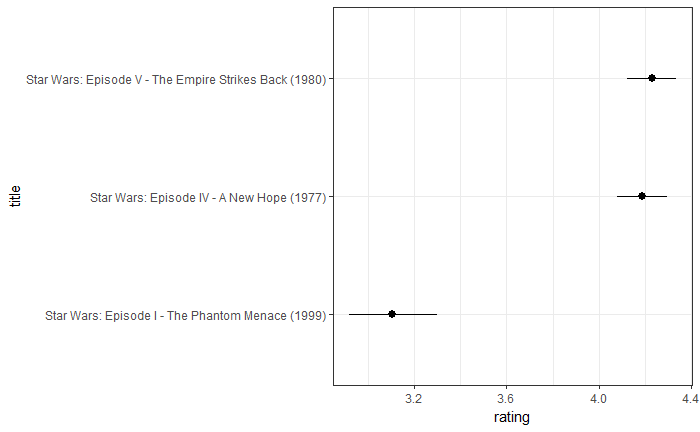

```r
sw = ratings %>% filter(grepl("Star Wars", title) &
                          (grepl("Episode IV -", title) |
                             grepl("Episode I -", title) |
                             grepl("Episode V -", title)))
ggplot(sw, aes(y = rating, x = title)) +
  stat_summary(fun.data = "mean_cl_boot") +
  coord_flip()
```

```r
nomes_episodios = c("Star Wars: Episode I - The Phantom Menace (1999)",
                    "", # não usamos
                    "", # não usamos
                    "Star Wars: Episode IV - A New Hope (1977)",
                    "Star Wars: Episode V - The Empire Strikes Back (1980)")

sw1x4 = sw %>%
  filter(title %in% c(nomes_episodios[1],
                      nomes_episodios[4])) %>%
  select(title, rating)
sw4x5 = sw %>%
  filter(title %in% c(nomes_episodios[4],
                      nomes_episodios[5])) %>%
  select(title, rating)
```

# Nosso framework

## Manual

```r
medias1x4 = sw1x4 %>%
  group_by(title) %>%
  summarise(media = mean(rating))

medias1x4

diff.media.observada.1x4 = diff(medias1x4$media)

medias4x5 = sw4x5 %>%
  group_by(title) %>%
  summarise(media = mean(rating))

medias4x5

diff.media.observada.4x5 = diff(medias4x5$media)
```

Episódio 1 x 4

```r
set.seed(1)
glimpse(sw1x4)
diffs = replicate(10000, {
  medias = sw1x4 %>%
    mutate(id_embaralhado = sample(title, n())) %>%
    group_by(id_embaralhado) %>%
    summarise(media = mean(rating))
  e1 = medias %>%
    filter(id_embaralhado == nomes_episodios[1])
  e4 = medias %>%
    filter(id_embaralhado == nomes_episodios[4])
  return(e1$media - e4$media)
})

tibble(diferenca = diffs) %>%
  ggplot(aes(x = diferenca)) +
  geom_histogram(bins = 30) +
  geom_vline(xintercept = diff.media.observada.1x4)

sum(abs(diffs) > abs(diff.media.observada.1x4)) / length(diffs)
```

Episódio 4 x 5

```r
set.seed(1)
glimpse(sw4x5)
diffs = replicate(10000, {
  medias = sw4x5 %>%
    mutate(id_embaralhado = sample(title, n())) %>%
    group_by(id_embaralhado) %>%
    summarise(media = mean(rating))
  e5 = medias %>%
    filter(id_embaralhado == nomes_episodios[5])
  e4 = medias %>%
    filter(id_embaralhado == nomes_episodios[4])
  return(e4$media - e5$media)
})

tibble(diferenca = diffs) %>%
  ggplot(aes(x = diferenca)) +
  geom_histogram(bins = 30) +
  geom_vline(xintercept = diff.media.observada.4x5, size = 2)

# Testamos com > porque a diferença encontrada foi positiva!
sum(abs(diffs) > abs(diff.media.observada.4x5)) / length(diffs)
```

## Pacote resample

```r
library(resample)

permutationTest2(sw1x4, mean(rating), treatment = title)
permutationTest2(sw4x5, mean(rating), treatment = title)

permutationTest2(sw1x4, median(rating), treatment = title)
permutationTest2(sw4x5, median(rating), treatment = title)
```

## Pacote coin

Teste da média

```r
library(coin)
oneway_test(rating ~ as.factor(title),
            data = sw4x5,
            distribution = "exact")
```

```
    Exact Two-Sample Fisher-Pitman Permutation Test

data:  rating by
     as.factor(title) (Star Wars: Episode IV - A New Hope (1977), Star Wars: Episode V - The Empire Strikes Back (1980))
Z = -0.51372, p-value = 0.6192
alternative hypothesis: true mu is not equal to 0
```

```r
oneway_test(rating ~ as.factor(title),
            data = sw4x5,
            distribution = "exact") %>%
  pvalue()
```

```
[1] 0.6192216
```

```r
pt = permutationTest2(sw4x5, mean(rating), treatment = title)
pt$stats$PValue
```

[output not shown]

Teste de que a mediana das populações de onde vieram as avaliações dos episódios são diferentes:

```r
median_test(rating ~ as.factor(title),
            data = sw4x5,
            distribution = "exact")
```

```
    Exact Two-Sample Brown-Mood Median Test

data:  rating by
     as.factor(title) (Star Wars: Episode IV - A New Hope (1977), Star Wars: Episode V - The Empire Strikes Back (1980))
Z = -0.024689, p-value = 1
alternative hypothesis: true mu is not equal to 0
```

```r
permutationTest2(sw4x5, median(rating), treatment = title)$stats %>% t()
```

```
            median(rating): Star Wars: Episode IV - A New Hope (1977)-Star Wars: Episode V - The Empire Strikes Back (1980)
Observed    "0"
Mean        "-0.01232623"
Alternative "two.sided"
PValue      "1"
```

## Por que two-tailed

Normalmente estamos interessados em rejeitar a hipótese nula da igualdade. A igualdade está em torno do zero, e portanto a rejeição acontece quando o valor observado está longe de zero em qualquer direção. Existem testes one-tailed que não dão informação sobre se há diferença nas duras direções. Porém na prática é uma prática requerida que você decida o teste antes de realizá-lo, e é difícil decidir que apenas diferenças em uma direção serão relevantes. Além disso, devido à pressão por resultado, decidir usar one-tailed é sempre um truque que aumenta sua chance de produzir um teste com diferença significativa, o que é claramente uma manipulação na sua metodologia.

# Testes conhecidos que você pode encontrar

# Mann-withney-wilcoxon

Testa se a soma dos ranks das duas amostras são significativamente diferentes.

```r
library("coin")
wilcox_test(rating ~ as.factor(title),
            data = sw4x5,
            distribution = "exact") # tirando este parâmetro, usamos fórmula fechada em lugar de permutação
```

## Chi-squared para associação entre duas variávies categóricas

```r
titanic = read.csv("dados/titanic.csv")
titanic = titanic %>%
  mutate(Survived = as.factor(Survived),
         Pclass = as.factor(Pclass))

table(titanic$Survived, titanic$Pclass)

chisq.test(titanic$Survived, titanic$Pclass, simulate.p.value = TRUE)

chisq.test(titanic$Survived, titanic$Pclass, simulate.p.value = TRUE)$resid

library(gmodels)
CrossTable(titanic$Survived,
           titanic$Pclass,
           prop.t = F,
           resid = TRUE)

# library(vcd)
#mosaic(table(titanic$Survived, titanic$Pclass), shade = TRUE)
```

Outro

```r
titanic2 <- read.csv(url("http://whitlockschluter.zoology.ubc.ca/wp-content/data/chapter09/chap09f1.1Titanic.csv"))
head(titanic2)
titanicTable <- table(titanic2$survival, titanic2$sex)
addmargins(titanicTable)

mosaicplot(t(titanicTable),
           cex.axis = 1,
           sub = "Sex",
           ylab = "Relative frequency", main = "")

library(vcd)
mosaic(table(titanic2$survival, titanic2$sex))
mosaic(HairEyeColor, shade = TRUE)
chisq.test(titanic2$sex, titanic2$survival, simulate.p.value = TRUE)
```